# Tugas 2 MPDW

## 2.4 Transformasi karna data tidak normal (1/x dan 1/y)

```r
volumetrans <- 1/(volume)
hightrans <- 1/(high)
lowtrans <- 1/(low)
## Model transformasi
modeltrans <- lm(volumetrans~hightrans+lowtrans)
summary(modeltrans)
```

```
##
## Call:
## lm(formula = volumetrans ~ hightrans + lowtrans)
##
## Residuals:
##        Min         1Q     Median         3Q        Max
## -1.213e-07 -4.044e-08 -2.020e-09  3.494e-08  3.754e-07
##
## Coefficients:
##               Estimate Std. Error t value Pr(>|t|)
## (Intercept) -2.245e-07  8.760e-08  -2.563   0.0111 *
## hightrans    2.655e-05  6.009e-06   4.419 1.64e-05 ***
## lowtrans    -2.118e-05  5.189e-06  -4.081 6.50e-05 ***
## ---
## Signif. codes:  0 '***' 0.001 '**' 0.01 '*' 0.05 '.' 0.1 ' ' 1
##
## Residual standard error: 6.509e-08 on 197 degrees of freedom
## Multiple R-squared:  0.1012, Adjusted R-squared:  0.09203
## F-statistic: 11.09 on 2 and 197 DF,  p-value: 2.741e-05
```

Model transforasi yang dihasilkan adalah
$$y_i=(-2.245e-07)+(
2.655e-05)x1_t+(-2.118e-05)x2_t$$
Berdasarkan ringkasan model dapat diketahui bahwa hasil uji F memiliki *p-value* < $\alpha$ (5%). Artinya, minimal terdapat satu variabel yang berpengaruh nyata terhadap model. Hasil uji-t parsial parameter regresi, yaitu koefisien regresi juga menunjukkan hal yang sama, yaitu memiliki *p-value* < $\alpha$ (5%) sehingga nyata dalam taraf 5%. Selanjutnya dapat dilihat juga nilai $R^2=0.1012$. Artinya, sebesar 10% keragaman nilai volume dapat dijelaskan oleh peubah high dan low. Namun, kita perlu melakukan uji terhadap sisaannya seperti berikut ini.

## 2.5 cek ulang normalitas

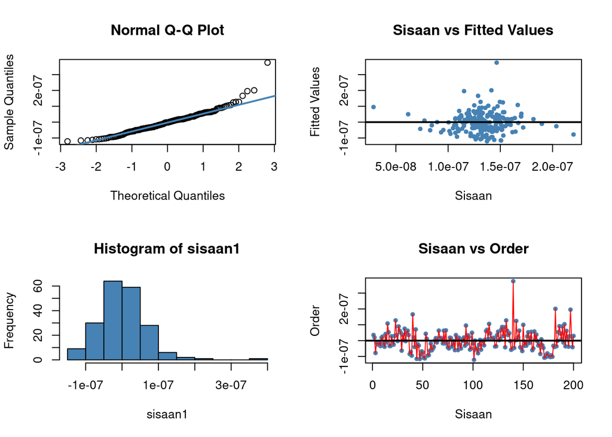

```r
##sisaan dan fitted value
sisaan1<- residuals(modeltrans)
fitValue1<- predict(modeltrans)

##Diagnostik dengan eksploratif
par(mfrow = c(2,2))
qqnorm(sisaan1)
qqline(sisaan1, col = "steelblue", lwd = 2)
plot(fitValue1, sisaan1, col = "steelblue", pch = 20, xlab = "Sisaan", ylab = "Fitted Values", main = "Sisaan vs Fitted Values")
abline(a = 0, b = 0, lwd = 2)
hist(sisaan1, col = "steelblue")
plot(seq(1,200,1), sisaan1, col = "steelblue", pch = 20, xlab = "Sisaan", ylab = "Order", main = "Sisaan vs Order")
lines(seq(1,200,1), sisaan1, col = "red")
abline(a = 0, b = 0, lwd = 2)
```

```r
## Uji Formal normalitas
##H0: sisaan mengikuti sebaran normal
##H1: sisaan tidak mengikuti sebaran normal
ks.test(sisaan1, "pnorm", mean=mean(sisaan1), sd=sd(sisaan1))
```

```
##
##  One-sample Kolmogorov-Smirnov test
##
## data:  sisaan1
## D = 0.061068, p-value = 0.4449
## alternative hypothesis: two-sided
```

## 2.6 ACF dan PACF identifikasi autokorelasi

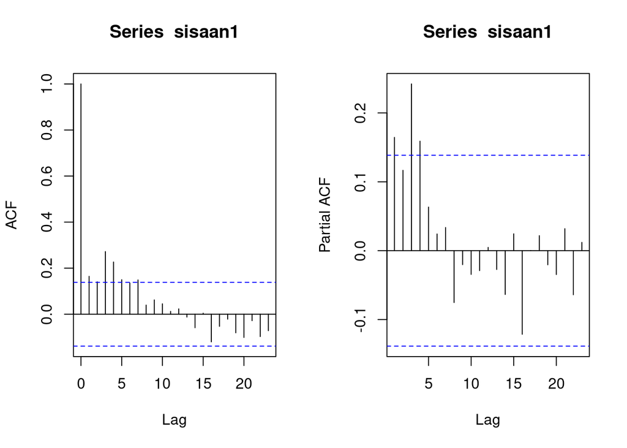

```r
par(mfrow = c(1,2))
acf(sisaan1)
pacf(sisaan1)
```

Berdasarkan plot ACF dan PACF, terlihat terdapat data yang berada diluar rentang batas sehingga ada yang signifikan. Namun, untuk lebih memastikan akan dilakukan uji formal dengan uji Durbin Watson.

## 2.7 Uji formal autokorelasi

```r
##H0: tidak ada autokorelasi
##H1: ada autokorelasi
dwtest(modeltrans)
```

```
##
##  Durbin-Watson test
##
## data:  modeltrans
## DW = 1.6684, p-value = 0.007217
## alternative hypothesis: true autocorrelation is greater than 0
```

Berdasarkan hasil DW Test, didapatkan nilai $DW = 1.6684$ dan *p-value* = $0.007217$. Dengan nilai *p-value* < 0.05 dapat disimpulkan bahwa tolak H0, cukup bukti mengatakan adanya autokorelasi. Oleh karena itu, diperlukan penangan autokorelasi. Penanganan yang akan digunakan menggunakan dua metode, yaitu Cochrane-Orcutt dan Hildret-Lu.

# 3 Penanganan Autokorelasi

## 3.1 Metode Cochrane-Orcutt

```r
##Penanganan Autokorelasi Cochrane-Orcutt
modelCO1<-cochrane.orcutt(modeltrans)
modelCO1
```

```
## Cochrane-orcutt estimation for first order autocorrelation
##
## Call:
## lm(formula = volumetrans ~ hightrans + lowtrans)
##
##  number of interaction: 6
##  rho 0.172226
##
## Durbin-Watson statistic
## (original):    1.66844 , p-value: 7.217e-03
## (transformed): 2.03940 , p-value: 5.83e-01
##
##  coefficients:
## (Intercept)   hightrans    lowtrans
##     0.0e+00     2.3e-05    -1.9e-05
```

```r
modelCO1$coefficients
```

```
##   (Intercept)     hightrans      lowtrans
## -1.845758e-07  2.333127e-05 -1.856671e-05
```

Hasil keluaran model setelah dilakukan penanganan adalah sebagai berikut.
$$y_i=(-1.845758e-07)+(2.333127e-05)x1_t+(-1.856671e-05)x2_t$$
Hasil juga menunjukkan bahwa nilai DW dan p-value meningkat menjadi $2.03940$ dan $5.83e-01$. dengan nilai *p-value* > 0.05, artinya belum cukup bukti menyatakan bahwa sisaan terdapat autokorelasi pada taraf nyata 5%. Untuk nilai $ρ ̂$ optimum yang digunakan adalah $0.1722264$. Nilai tersebut dapat diketahui dengan *syntax* berikut.

```r
##Rho optimum
rho1<- modelCO1$rho
rho1
```

```
## [1] 0.1722264
```

## 3.2 Transformasi manual

```r
##Transformasi Manual
volume.trans<- volumetrans[-1]-volumetrans[-200]*rho1
high.trans<- hightrans[-1]-hightrans[-200]*rho1
low.trans<- lowtrans[-1]-lowtrans[-200]*rho1
modelCOmanual1<- lm(volume.trans~high.trans+low.trans)
summary(modelCOmanual1)
```

```
##
## Call:
## lm(formula = volume.trans ~ high.trans + low.trans)
##
## Residuals:
##        Min         1Q     Median         3Q        Max
## -1.243e-07 -4.166e-08 -6.010e-09  3.423e-08  3.860e-07
##
## Coefficients:
##               Estimate Std. Error t value Pr(>|t|)
## (Intercept) -1.528e-07  8.311e-08  -1.838 0.067514 .
## high.trans   2.333e-05  6.094e-06   3.829 0.000173 ***
## low.trans   -1.857e-05  5.261e-06  -3.529 0.000519 ***
## ---
## Signif. codes:  0 '***' 0.001 '**' 0.01 '*' 0.05 '.' 0.1 ' ' 1
##
## Residual standard error: 6.427e-08 on 196 degrees of freedom
## Multiple R-squared:  0.07497,    Adjusted R-squared:  0.06554
## F-statistic: 7.943 on 2 and 196 DF,  p-value: 0.000482
```

```r
##Mencari Penduga Koefisien Regresi setelah Transformasi ke Persamaan Awal
b0bintang1 <- modelCOmanual1$coefficients[1]
b0.1<- b0bintang1/(1-rho1)
b1.1 <- modelCOmanual1$coefficients[2]
b2.1 <- modelCOmanual1$coefficients[3]
b0.1
```

```
##   (Intercept)
## -1.845758e-07
```

```r
b1.1
```

```
##   high.trans
## 2.333127e-05
```

```r
b2.1
```

```
##     low.trans
## -1.856671e-05
```